# vertica.dplyr

vertica.dplyr is an R package developed by Hewlett-Packard that provides HP Vertica backend support for the [dplyr](http://cran.r-project.org/web/packages/dplyr/index.html) package. dplyr provides tools for data wrangling using R data frames. With vertica.dplyr, users can now do the same in Vertica tables without moving the data into R. vertica.dplyr also provides the following additional features to simplify working with HP Vertica and HP Distributed R:

- [HPdata](http://www.vertica.com/wp-content/uploads/2014/06/HPdata-Manual.pdf)-style functions (data transport from HP Vertica to HP Distributed R via the data loader), namely tbl2d**object** (where **object** is either **array** or **frame**), that are compatible with dplyr tbl objects.
- Easy CSV loading into HP Vertica.
- copy_to functionality that takes advantage of HP Vertica's fast **COPY LOCAL** feature.
- Connectivity to HP Vertica through either JDBC or ODBC.

A brief background of the dplyr package is provided in the following section.

### What is dplyr?

*To learn more, read the [dplyr vignette](http://cran.rstudio.com/web/packages/dplyr/vignettes/introduction.html).*

dplyr offers convenient methods of manipulating data frames, which can be correlated to tables in a database. Common actions in dplyr include what are known as the “verbs” of the package.

For single data.frames (or tables):

1. **filter**
   - Filters tables by rows matching certain criteria (e.g., filter(table,col1 > 5, col2 ==3)), equivalent to (**SELECT** … from table **WHERE** …)
2. **arrange**
   - Orders rows (for example, arrange(tbl,desc(col1)))
3. **select**
   - Selects columns (for example, select(tbl,'col1','col2'))
4. **mutate**
   - Create new columns (for example, mutate(tbl,new_col1=col3/col2,new_col2=fun(col4,col5)))
5. **summarise** (or **summarize**)
   - Collapses rows belonging to a certain group into a single one (for example, for aggregations)
   - Analogous to **GROUP BY**

There are also verbs for multiple tables, such as left_join(), inner_join(), semi_join(), anti_join(), union(), intersect().

### HP Vertica Integration

For data that resides in a database, dplyr provides an interface to access tables and manipulate them directly inside the database as though they were local data frames. The dplyr package provides support for MySQL, Postgres, BigQuery, and SQLite backends. vertica.dplyr enables dplyr to work with HP Vertica.

vertica.dplyr adds dplyr-support for HP Vertica, as well as serving as the basic “intermediary” between R (and HP Distributed R) and HP Vertica, which includes data preparation, data transfer, and HP Vertica function invocation.

## Obtaining the Package

You can obtain vertica.dplyr from [Github](https://github.com/vertica/vertica.dplyr).

### Prerequisites

vertica.dplyr has 2 hard dependencies: [assertthat](http://cran.r-project.org/web/packages/assertthat/index.html) and [dplyr](http://cran.r-project.org/web/packages/dplyr/index.html). There are additional **soft** dependencies on vRODBC, [RJDBC](http://cran.r-project.org/web/packages/RJDBC/index.html), and [HPdata](http://www.vertica.com/wp-content/uploads/2014/06/HPdata-Manual.pdf).

**Soft** means that there is no enforcement of having these packages installed on the user's system to install vertica.dplyr. However, to use vertica.dplyr, at least one of **RJDBC** or **vRODBC** must be installed and configured. These **soft** dependencies are loaded (at which point it is required to have the package installed) when their specific functionality is invoked. For example, when creating a vertica.dplyr connection to HP Vertica with ODBC, vertica.dplyr checks to make sure that **vRODBC** is installed and loadable. If it isn't, an error is thrown.

You also need access to an HP Vertica database (must be configured separately), as well as either (or both) the ODBC or JDBC HP Vertica driver(s) installed and configured on your host machine (the one that runs vertica.dplyr). Please refer to external documentation for help with these steps. A guide is available at [this](http://my.vertica.com/docs/DISTR/1.1.x/HTML/index.htm#DistributedR/InstallingDistributedR/Installing_vRODBC/Installing_vRODBC.htm) link.

# Using vertica.dplyr

The following example demonstrates some of the fundamental data manipulation features of vertica.dplyr (and dplyr).

First, load the package in R:

```r
# Load the vertica.dplyr package, which loads dplyr as a dependency
library(vertica.dplyr)
```

Note that a few of the imported dplyr functions have names that overwrite their R-base equivalents.

## Connect to HP Vertica

First, connect to HP Vertica using the `src_vertica` function. There are two ways to do this:

### Via ODBC (requires **vRODBC**):

```r
# Connect to HP Vertica using vRODBC
vertica_odbc <- src_vertica("VerticaDSN")
```

### Via JDBC (requires **RJDBC**):

```r
# Connect to HP Vertica using RJDBC
vertica_jdbc <- src_vertica(dsn = NULL, jdbcpath="/opt/vertica/java/lib/vertica_jdbc.jar","foobar","localhost",5433,"dbadmin")
```

In this example, you connect to an HP Vertica DB instance named “foobar” that is listening on port 5433, with db-owner username “dbadmin”, and no password. The ODBC version is much more brief, because all of the configuration details are settled inside of ODBC.ini on the system, and you only need to provide the DSN. Note that if `dsn` is NULL, it is assumed that JDBC is to be used.

Both `vertica_jdbc` and `vertica_odbc` are `src_vertica` objects, and vertica.dplyr functionality works on both object types interchangeably. The only differences are how the package prints some metadata when you look at these objects,

```r
# show differences
vertica_odbc
```

```
## src:  Vertica ODBC Connection
## -----+DSN: VerticaDSN
## -----+Host: 127.0.0.1
## -----+DB Version: 07.01.0002
## -----+ODBC Version: 03.80
## tbls: AllstarFull, asdf, AwardsManagers, AwardsPlayers,
##   AwardsShareManagers, AwardsSharePlayers, bank_original,
##   compute_test_table, d1, d2, Fielding, FieldingOF, FieldingPost,
##   HallOfFame, LahmanData, Managers, ManagersHalf, Master, Pitching,
##   PitchingPost, ref_join, Salaries, Schools, SchoolsPlayers, SeriesPost,
##   TeamsFranchises, tempName, test, tsempName
```

```r
vertica_jdbc
```

```
## src:  Vertica JDBC Connection [dbadmin@localhost:5433/foobar]
## tbls: AllstarFull, asdf, AwardsManagers, AwardsPlayers,
##   AwardsShareManagers, AwardsSharePlayers, bank_original,
##   compute_test_table, d1, d2, Fielding, FieldingOF, FieldingPost,
##   HallOfFame, LahmanData, Managers, ManagersHalf, Master, Pitching,
##   PitchingPost, ref_join, Salaries, Schools, SchoolsPlayers, SeriesPost,
##   TeamsFranchises, tempName, test, tsempName
```

as well as whether or not `dsn` is required as a parameter for `tbl2dframe`, `tbl2darray`, and `tbl2darrays`.

As you can see, both connection options print information about the connection and list the current user tables (and views) found in the database. For the rest of this example, the ODBC version is used and it is called `vertica`:

```r
vertica <- vertica_odbc
class(vertica)
```

```
## [1] "src_vertica" "src_sql"     "src"
```

## vertica.dplyr “tables” (tbl_vertica)

The following are some basic principles of a “tbl”:

- The basic dplyr object is the “tbl” (or in this case, tbl_vertica). This is a reference to SQL, some not-yet executed query that results in a new table.
- Conceptually, a “tbl_vertica” object is nothing more than a wrapper object that contains a SQL query, a connection to a DB, and related internal metadata. These tables behave in the same manner as data.frames would when used in dplyr, except now they are actually meant to be executed in database.
- Most operations (excluding those that convert tbls to data.frames, or saves them to tables/view in HP Vertica, or converts them to dobjects in Distributed R) performed on a tbl result in another tbl. Essentially, you can chain these operations together, meaning that the SQL statement builds up in complexity.
- Tbl objects are lazily executed on the DB; that is, when you do not require the results (for example, moving the results to R, or looking at the data by printing the results in R), nothing is executed in HP Vertica.

## Retrieving a tbl reference

One way to get started with a tbl_vertica object is to directly access an existing table. For example, you can access the “Salaries” table listed above in the printout of our src_vertica objects. To do this, use the `tbl` function on the `src_vertica` object. This table is from the `Lahman` package available on [CRAN](http://cran.r-project.org/web/packages/Lahman/index.html).

```r
salaries <- tbl(vertica,"Salaries")
```

`salaries` now contains a simple select statement on “Salaries” in HP Vertica. You can examine the SQL query associated with a `tbl_vertica` by accessing the `query` member of the object:

```r
salaries$query
```

```
## <Query> SELECT "yearID", "teamID", "lgID", "playerID", "salary"
## FROM "Salaries"
## An object of class "VerticaConnection"
## Slot "conn":
## vRODBC Connection 10
## Details:
##   case=nochange
##   DSN=VerticaDSN
##
## Slot "type":
## [1] "ODBC"
```

As mentioned before, nothing is yet executed in DB. If, however, you would like to see what the data looks like, you can ask R to print `salaries`.

```r
salaries
```

```
## Source: Vertica ODBC Connection
## -----+DSN: VerticaDSN
## -----+Host: 127.0.0.1
## -----+DB Version: 07.01.0002
## -----+ODBC Version: 03.80
## From: Salaries [23,956 x 5]
##
##    yearID teamID lgID  playerID salary
## 1    1985    ATL   NL barkele01 870000
## 2    1985    ATL   NL bedrost01 550000
## 3    1985    ATL   NL benedbr01 545000
## 4    1985    ATL   NL  campri01 633333
## 5    1985    ATL   NL ceronri01 625000
## 6    1985    ATL   NL chambch01 800000
## 7    1985    ATL   NL dedmoje01 150000
## 8    1985    ATL   NL forstte01 483333
## 9    1985    ATL   NL garbege01 772000
## 10   1985    ATL   NL harpete01 250000
## ..    ...    ...  ...       ...    ...
```

The query is actually executed in the database, and the first few rows can be seen in the result (dplyr automatically takes the HEAD and displays it).

The primary way to view data is by accessing data already in database. An alternative workflow is to start with data in R and copy it to HP Vertica using `copy_to`. You can also start from a CSV file and load it into HP Vertica using `db_load_from_file`.

Start with data from all NYC flights in the year 2013, which you can get from the R package [`nycflights13`](http://cran.r-project.org/web/packages/nycflights13/index.html). Importing the library imports an R data.frame, `flights`.

```r
library(nycflights13)
# Peek at data.frame `flights`
head(flights,10)
```

```
## Source: local data frame [10 x 16]
##
##    year month day dep_time dep_delay arr_time arr_delay carrier tailnum
## 1  2013     1   1      517         2      830        11      UA  N14228
## 2  2013     1   1      533         4      850        20      UA  N24211
## 3  2013     1   1      542         2      923        33      AA  N619AA
## 4  2013     1   1      544        -1     1004       -18      B6  N804JB
## 5  2013     1   1      554        -6      812       -25      DL  N668DN
## 6  2013     1   1      554        -4      740        12      UA  N39463
## 7  2013     1   1      555        -5      913        19      B6  N516JB
## 8  2013     1   1      557        -3      709       -14      EV  N829AS
## 9  2013     1   1      557        -3      838        -8      B6  N593JB
## 10 2013     1   1      558        -2      753         8      AA  N3ALAA
## Variables not shown: flight (int), origin (chr), dest (chr), air_time
##   (dbl), distance (dbl), hour (dbl), minute (dbl)
```

```r
nrow(flights)
```

```
## [1] 336776
```

Copy it over to HP Vertica using `copy_to` and view the result:

```r
flights_vertica <- copy_to(vertica,flights,"flights")
flights_vertica
```

```
## Source: Vertica ODBC Connection
## -----+DSN: VerticaDSN
## -----+Host: 127.0.0.1
## -----+DB Version: 07.01.0002
## -----+ODBC Version: 03.80
## From: flights [336,776 x 16]
##
##    year month day dep_time dep_delay arr_time arr_delay carrier tailnum
## 1  2013     1   1      517         2      830        11      UA  N14228
## 2  2013     1   1      533         4      850        20      UA  N24211
## 3  2013     1   1      542         2      923        33      AA  N619AA
## 4  2013     1   1      544        -1     1004       -18      B6  N804JB
## 5  2013     1   1      554        -6      812       -25      DL  N668DN
## 6  2013     1   1      554        -4      740        12      UA  N39463
## 7  2013     1   1      555        -5      913        19      B6  N516JB
## 8  2013     1   1      557        -3      709       -14      EV  N829AS
## 9  2013     1   1      557        -3      838        -8      B6  N593JB
## 10 2013     1   1      558        -2      753         8      AA  N3ALAA
## ..  ...   ... ...      ...       ...      ...       ...     ...     ...
## Variables not shown: flight (dbl), origin (chr), dest (chr), air_time
##   (dbl), distance (dbl), hour (dbl), minute (dbl)
```

`copy_to` has automatically extracted the data types in the data.frame, converted them to a schema in HP Vertica, created the table in HP Vertica, and copied it over to the DB. It returns another tbl_vertica object which, in this case, is named `flights_vertica`.

## Small “data-prep” example using flights data

As one of the most densely populated regions in the United States, the New York metropolitan area is serviced by three major airports: JFK, Newark (EWR), and LaGuardia (LGA). Delays in flights are unavoidable, but do any of these airports have an edge over the others? How is flight delay affected by the time of year?

To help answer these inquiries, you may conduct a simple statistical analysis of the flight records in the year 2013.

Examining the `flights_vertica` table, you can see that it has labeled each flight by some values such as date, departure/arrival times, and distance.

### Select: Select columns from a table.

One basic operation is the *select* function. When connected to a database, this issues a corresponding SQL `SELECT` on the specified table, with the specified columns.

```r
# Select columns month, day, arr_delay, and origin
q1 <- select(flights_vertica, year, month, day, origin, arr_delay)
q1
```

```
## Source: Vertica ODBC Connection
## -----+DSN: VerticaDSN
## -----+Host: 127.0.0.1
## -----+DB Version: 07.01.0002
## -----+ODBC Version: 03.80
## From: flights [336,776 x 5]
##
##    year month day origin arr_delay
## 1  2013     1   1    EWR        11
## 2  2013     1   1    LGA        20
## 3  2013     1   1    JFK        33
## 4  2013     1   1    JFK       -18
## 5  2013     1   1    LGA       -25
## 6  2013     1   1    EWR        12
## 7  2013     1   1    EWR        19
## 8  2013     1   1    LGA       -14
## 9  2013     1   1    JFK        -8
## 10 2013     1   1    LGA         8
## ..  ...   ... ...    ...       ...
```

### Filter: Select rows matching provided criteria

To answer the first question (determining which airport has the worst delays), you want to examine only the flights that occur between the months of February and November. During the holiday season (approximately December through January), delays may be influenced by the increase in traveling, and such data may bias the result.

Since the `select` operation from before returned another dplyr tbl object, you can chain that object with the following `filter` operation by passing in `q1` as its first argument.

```r
# Filter out flights in January and December
q2 <- filter(q1, year == 2013, month > 1, month < 12)
q2
```

```
## Source: Vertica ODBC Connection
## -----+DSN: VerticaDSN
## -----+Host: 127.0.0.1
## -----+DB Version: 07.01.0002
## -----+ODBC Version: 03.80
## From: flights [281,637 x 5]
## Filter: year == 2013, month > 1, month < 12
##
##    year month day origin arr_delay
## 1  2013     2   1    LGA        NA
## 2  2013     2   1    EWR        NA
## 3  2013     2   1    EWR        NA
## 4  2013     2   1    EWR        NA
## 5  2013     2   1    EWR        NA
## 6  2013     2   1    EWR        NA
## 7  2013     2   1    EWR        NA
## 8  2013     2   1    EWR        NA
## 9  2013     2   1    EWR        NA
## 10 2013     2   1    EWR        NA
## ..  ...   ... ...    ...       ...
```

The data now printed out show flights beginning with the first of February. Just as when you retrieved a reference to an HP Vertica table, you can view the query associated with this filter operation:

```r
# Look at what we did in terms of SQL
q2$query
```

```
## <Query> SELECT "year" AS "year", "month" AS "month", "day" AS "day", "origin" AS "origin", "arr_delay" AS "arr_delay"
## FROM "flights"
## WHERE "year" = 2013.0 AND "month" > 1.0 AND "month" < 12.0
## An object of class "VerticaConnection"
## Slot "conn":
## vRODBC Connection 10
## Details:
##   case=nochange
##   DSN=VerticaDSN
##
## Slot "type":
## [1] "ODBC"
```

As may be expected, the query resulting from a **filter** involves a `WHERE` clause.

Notice that `arr_delay` has NA values for many rows, which are NULL in HP Vertica. Get rid of these rows with incomplete data using another `filter` operation on `q2`:

```r
# Filter out NA rows
q3 <- filter(q2,!is.na(arr_delay))
q3
```

```
## Source: Vertica ODBC Connection
## -----+DSN: VerticaDSN
## -----+Host: 127.0.0.1
## -----+DB Version: 07.01.0002
## -----+ODBC Version: 03.80
## From: flights [273,928 x 5]
## Filter: year == 2013, month > 1, month < 12, !is.na(arr_delay)
##
##    year month day origin arr_delay
## 1  2013     2   1    EWR         4
## 2  2013     2   1    EWR        -4
## 3  2013     2   1    LGA         8
## 4  2013     2   1    JFK       -10
## 5  2013     2   1    JFK         9
## 6  2013     2   1    EWR       -14
## 7  2013     2   1    JFK        -1
## 8  2013     2   1    LGA         9
## 9  2013     2   1    LGA         0
## 10 2013     2   1    LGA        -4
## ..  ...   ... ...    ...       ...
```

There are no longer any NA values. dplyr has converted the R-style boolean expression on `arr_delay` for `NA` values into `NOT NULL` in SQL.

### Summarise, group_by, and arrange: GROUP BY airports and ORDER them by average delay

Now that the data has been cleaned up, you can find which airport had the worst delays going out of New York City in 2013, between the months of February and November.

Essentially, these operations are equivalent to running AVG and GROUP BY operations on these columns. In this example, you use the dplyr equivalent.

First, use `group_by`, which constructs the grouping clause, followed by a summarise (which takes a group_by clause as its first argument) to generate the report. Along with the report, you can also create new columns for determining the number of flights belonging to each airport (call this `count`), as well as the average delay for that airport (called delay).

```r
# Group by airport (origin)
by_origin <- group_by(q3, origin)
q4 <- summarise(by_origin,
   count = n(),
   delay = mean(arr_delay)
)
```

The `summarise` function allows you to create two new columns, `count` and `delay` as functions of the `GROUP BY origin` created by `group_by`, which you store as `by_origin`. The arguments on the right-hand side, `n` and `mean`, correspond to the vertica.dplyr bindings of the HP Vertica analytic functions you are invoking (**COUNT(*)** and **AVG(arr_delay)**).

Before you look at the result, rank these airports by worst (most delay) to best using `arrange`:

```r
# Average delays by airport
q5 <- arrange(q4,desc(delay))
q5
```

```
## Source: Vertica ODBC Connection
## -----+DSN: VerticaDSN
## -----+Host: 127.0.0.1
## -----+DB Version: 07.01.0002
## -----+ODBC Version: 03.80
## From: <derived table> [?? x 3]
## Arrange: desc(delay)
##
##    origin count    delay
## 1     EWR 98101 7.733132
## 2     LGA 84702 5.370121
## 3     JFK 91125 5.268258
## ..    ...   ...      ...
```

### Lazy execution

Now look again at the query by accessing `$query` of a `tbl` object. Use the `q5` variable.

```r
q5$query
```

```
## <Query> SELECT "origin", "count", "delay"
## FROM (SELECT "origin", count(*) AS "count", AVG("arr_delay") AS "delay"
## FROM "flights"
## WHERE "year" = 2013.0 AND "month" > 1.0 AND "month" < 12.0 AND NOT("arr_delay"IS NULL)
## GROUP BY "origin") AS "_W22"
## ORDER BY "delay" DESC
## An object of class "VerticaConnection"
## Slot "conn":
## vRODBC Connection 10
## Details:
##   case=nochange
##   DSN=VerticaDSN
##
## Slot "type":
## [1] "ODBC"
```

Note that this query is a complex query that has been built off of the initial tbl created by the `copy_to` statement since before the data preparation began. This means that, if all of the intermediate results had not been printed in console, *nothing from q1 through q5 would have even touched the DB*.

### Collect: Bringing it back to R

To bring this data back into the R console, use `collect`. `collect` takes the saved query, executes it on the database, and brings the results back into R as a data.frame.

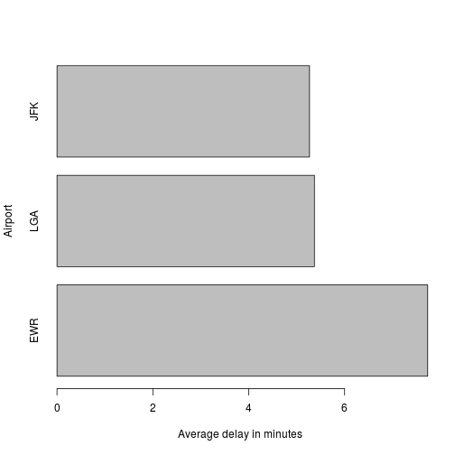

```r
# Bring results back into R as a data.frame, then plot the results
airport_delays <- collect(q5)
barplot(airport_delays[["delay"]],horiz=TRUE,
      names.arg=airport_delays[["origin"]],
     xlab="Average delay in minutes",ylab="Airport")
```

## Calling HP Vertica Functions

In the previous sections, AVG (called as mean()) in dplyr) as well as COUNT(*) (invoked with n() in dplyr) were used with the `summarise` function. This section describes in more detail how HP Vertica functions can be invoked, namely window and aggregate functions, on different partitions of data.

Note that a complete list of currently supported functions may be found at the end of this document.

In general, a function can be invoked by simply dropping it into any `mutate` or `summarise` statement. `mutate` adds an entire column to your tbl, so use it when you expect to get a vector of results back from your function. For example, when invoking a window function. Meanwhile, `summarise` collapses all rows (belonging to a group) into one (therefore, if no `group_by` is used, your function runs on all rows of your table).

### Aggregate Functions

An aggregate function needs to be invoked with `summarise`, which necessitates the additional use of `group_by` to specify the groups on which to aggregate. If it is not used with any `group_by` result, the function runs on the entire table, leaving you with only one result.

If you have a function `foo` that you wish to run on attribute `attr` in `tbl`, grouping by column `col`, with additional arguments `args`, run:

```r
grouped_by_col <- group_by(tbl,col)
result <- summarise(grouped_by_col,new_col = foo(attr,args))
```

Occasionally, the function may not take the `attr` argument, or any arguments at all (such as COUNT(*)). In this case, no args need to be passed, for example, `new_col = n()` for `COUNT(*)`.

Notice that a new column is created named `new_col`. This can be done using `mutate` as well.

### Window Functions

The **PARTITION BY** SQL statement is also constructed by `group_by`. This means that, for window functions requiring such a clause (which is most), it is recommended to run a `group_by` on the column you wish to partition by (although, this can be overridden using the `partition` parameter).

In addition to this, many window functions also have some notion of a *“window”* of a specified width over which the function is applied. In HP Vertica, many of them (even those that do not require explicit ordering) require an obligatory ORDER BY clause when they are invoked.

For this reason, the syntax for running a window function on HP Vertica through dplyr is unique to vertica.dplyr.

In standard dplyr syntax, you need a `group_by` call followed by a `mutate` or `filter`. To run a window function `winfun` on column `col` of table `tbl`, partitioning by `partcol`, invoke it in the following manner:

```r
grouped_by_partcol <- group_by(tbl,partcol)
mutate(grouped_by_partcol, new_col = winfun(col,args))
```

You may notice that this does not enforce any particular ordering nor windowing range on the function. Because most HP Vertica functions require the **ORDER BY** statement, in vertica.dplyr there is a way to make this happen in your invocation of the window function, using the `order` argument.

Similarly, you can specify your window size using `range`. This is usually an optional argument (leaving this alone causes an attempt to run the function with no window size specified), but it is useful when it is needed.

Using both of these arguments, with the assumption that we want to have the range between `min` and `max`, ordering by `ordercol`, the above flow is converted to the following in vertica.dplyr:

```r
grouped_by_partcol <- group_by(tbl,partcol)
mutate(grouped_by_partcol, new_col = winfun(col,args,range=c(min,max),order=ordercol))
```

The following also has the same effect, since `partition` also allows you to specify partitioning:

```r
mutate(tbl, new_col = winfun(col,args,range=c(min,max),partition=partcol,order=ordercol))
```

Note that the range is specified as an R vector. `-Inf` is converted to `ROWS UNBOUNDED PRECEDING`, `Inf` is converted to `ROWS UNBOUNDED FOLLOWING`.

#### Hands-on Example

The following example demonstrates how delays changed over the calendar year. Return to the flights example, and grab query `q1`. To determine our result, it is necessary to complete the following steps:

1. Remove unnecessary columns and NULL values
2. Average all delays for every unique calendar day
3. To get a more “smoothed” result, run another average function over these delay values, with a running window width of 10 days (5 days prior to the current row, and 5 days after).

```r
c <- filter(select(q1,month,day,arr_delay),!is.na(arr_delay))
calendar_day <- group_by(c,month,day)
delay_by_day <- summarise(calendar_day,avg_delay = mean(arr_delay))
delays <- mutate(delay_by_day, delay_smoothed = mean(avg_delay,range=c(-5,5),
partition=NULL,order=c(month,day)))
delays
```

```
## Source: Vertica ODBC Connection
## -----+DSN: VerticaDSN
## -----+Host: 127.0.0.1
## -----+DB Version: 07.01.0002
## -----+ODBC Version: 03.80
## From: <derived table> [?? x 4]
## Grouped by: month
##
##    month day  avg_delay delay_smoothed
## 1      1   1 12.6510229      5.3091754
## 2      1   2 12.6928879      3.8439629
## 3      1   3  5.7333333      2.9600202
## 4      1   4 -1.9328194      2.6017649
## 5      1   5 -1.5258020      1.7517068
## 6      1   6  4.2364294      1.1595273
## 7      1   7 -4.9473118     -1.1738523
## 8      1   8 -3.2275785     -0.9703107
## 9      1   9 -0.2642777     -1.1605861
## 10     1  10 -5.8988159     -0.9461796
## ..   ... ...        ...            ...
```

Now, plot `delay_smoothed`.

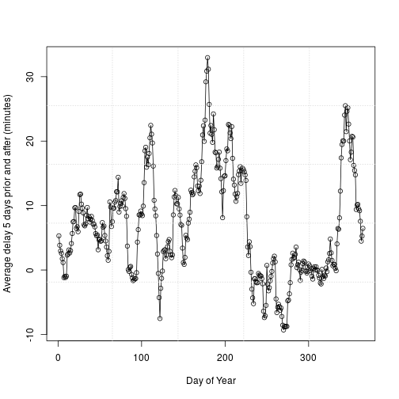

```r
delays_local <- collect(delays)
plot(delays_local[["delay_smoothed"]],xlab="Day of Year",
ylab="Average delay 5 days prior and after (minutes)")
lines(delays_local[["delay_smoothed"]])
grid(nx=5)
```

For a list of functions that are currently tested to work in vertica.dplyr and their mappings to internal HP Vertica functions, please refer to the appropriately titled section at the end of this document.

**Note: Pay particular attention to types. By default, numbers passed into R functions are of type numeric, and these do not work with HP Vertica functions that require integer values. To pass integer values, you must use “L” after the number in R, for example, `func(2L,3L)`.**

## User-Defined Functions

vertica.dplyr also allows user-defined functions (UDFs) in HP Vertica to be run. `list_udf()` will allow you to take a `src_vertica` connection object and will return to you a list of currently registered UDFs. This will return a data frame of UDFs, as well as their types. To invoke a UDF, simply follow the same conventions as the other functions mentioned above (using mutate or select). UDFs take in optional *parameters*, as specified in Vertica with a `USING PARAMETERS` clause following the normal function arguments. To supply these parameters, supply a `list()` in R to the `params` argument in the function, corresponding to a key-value mapping for the parameters, for example, as below:

```
table <- tbl(vertica,"some_table")
result <- mutate(table,fun=some_udf(col1,col2,params=list(param1='x',foo=3,bar=3.4)))
```

The above example will result in a `SELECT` on the columns of `table` and `SOME_UDF(col1,col2 USING PARAMETERS param1='x', foo=3, bar=3.4) AS fun`.

## Other functionality

The previous examples demonstrate how to access tables and manipulate them with some of the most common vertica.dplyr functions. The examples include a general template for how to invoke HP Vertica functions.

The following examples go over some of the additional things that can be done using vertica.dplyr.

Many of the functions described below take a `VerticaConnection` object, meaning something that may be accessed by retrieving the `con` member of your `src_vertica` object. In the previous examples, this would be `vertica$con`.

## Select statements without FROM

For several HP Vertica functions or external procedures, the invocation is one without a `FROM` clause. To invoke them with vertica.dplyr, supply a `select` statement with the first argument a `src_vertica` object, as opposed to a `tbl_vertica`; for example:

```r
select(vertica,user=user())
```

```
## Source: Vertica ODBC Connection
## -----+DSN: VerticaDSN
## -----+Host: 127.0.0.1
## -----+DB Version: 07.01.0002
## -----+ODBC Version: 03.80
## From: <derived table> [?? x 1]
##
##       user
## 1  dbadmin
## ..     ...
```

### Creating a table in HP Vertica

More often than not, the data to be prepared already exists in HP Vertica. On some other occasions, you may want to copy data from your R instance to HP Vertica using `copy_to`. Other times, you might want to create a table of your own and take control over your schema and data types.

To do so, you need to create a character vector that describes the schema of your table, and invoke `db_create_table` with a `VerticaConnection`.

For example, to create a table named `New_Table`, with a schema of `INTEGER`, `VARCHAR`, and `VARCHAR` corresponding to columns `employeeID`, `name`, and `department`, run the following commands:

```r
types <- c("integer","varchar","varchar")
names(types) <- c("employeeID","name","department")
db_create_table(vertica$con,"New_Table",types)
```

### Loading from CSV

`db_load_from_file` provides a convenient way to load data from a file. To invoke it, it's necessary to know:

1. The name of the file (*example: foo.csv*)
2. Your `src_vertica` object (*example: `vertica`*)
3. The type of delimiter in the file (*example: ','*)
4. The number of lines to skip at the beginning of the file, which is useful for files with headings (*example: 1L*)
5. Whether to append this data to existing data in a table or overwrite it. (*example: TRUE*)
6. The name of the table into which you would like to load the data (*example: mytable*)

```r
db_load_from_file(vertica,"mytable","foo.csv",sep=",",skip=1L,append=TRUE)
```

Note that `mytable` must already exist, and the schema must be compatible with the data you are loading. At the moment, vertica.dplyr does **not** automatically scan your file for a schema and create an appropriate table for you.

### Listing, dropping, and checking tables

You can view, check for, and drop tables by using `db_list_tables`, `db_has_table`, and `db_drop_table`, respectively:

```r
db_list_tables(vertica$con)
```

```
##  [1] "AllstarFull"         "asdf"                "AwardsManagers"
##  [4] "AwardsPlayers"       "AwardsShareManagers" "AwardsSharePlayers"
##  [7] "bank_original"       "compute_test_table"  "d1"
## [10] "d2"                  "Fielding"            "FieldingOF"
## [13] "FieldingPost"        "flights"             "HallOfFame"
## [16] "LahmanData"          "Managers"            "ManagersHalf"
## [19] "Master"              "Pitching"            "PitchingPost"
## [22] "ref_join"            "Salaries"            "Schools"
## [25] "SchoolsPlayers"      "SeriesPost"          "TeamsFranchises"
## [28] "tempName"            "test"                "tsempName"
```

```r
db_has_table(vertica$con,"foobar")
```

```
## [1] FALSE
```

```r
db_has_table(vertica$con,"Salaries")
```

```
## [1] TRUE
```

```r
db_drop_table(vertica$con,"Salaries")
```

### Explaining Queries

Queries (tbl objects) can be explained using `explain`:

```r
explain(q5)
```

```
## <SQL>
## SELECT "origin", "count", "delay"
## FROM (SELECT "origin", count(*) AS "count", AVG("arr_delay") AS "delay"
## FROM "flights"
## WHERE "year" = 2013.0 AND "month" > 1.0 AND "month" < 12.0 AND NOT("arr_delay"IS NULL)
## GROUP BY "origin") AS "_W22"
## ORDER BY "delay" DESC
##
##
## <PLAN>
## ------------------------------ QUERY PLAN DESCRIPTION: ------------------------------
## EXPLAIN SELECT "origin", "count", "delay" FROM (SELECT "origin", count(*) AS "count", AVG("arr_delay") AS "delay" FROM "flights" WHERE "year" = 2013.0 AND "month" > 1.0 AND "month" < 12.0 AND NOT("arr_delay"IS NULL) GROUP BY "origin") AS "_W22" ORDER BY "delay" DESC
## Access Path:+-SORT [Cost: 220K, Rows: 3] (PATH ID: 1)
## |  Order: _W22.delay DESC
## | +---> GROUPBY HASH (LOCAL RESEGMENT GROUPS) [Cost: 220K, Rows: 3] (PATH ID: 3)
## | |      Aggregates: max(flights.origin), count(*), sum_float(flights.arr_delay), count(flights.arr_delay)
## | |      Group By: collation(flights.origin, 'en_US')
## | | +---> STORAGE ACCESS for flights [Cost: 219K, Rows: 280K] (PATH ID: 4)
## | | |      Projection: public.flights_super
## | | |      Materialize: flights.arr_delay, flights.origin
## | | |      Filter: (flights.year = 2013.0)
## | | |      Filter: ((flights.month > 1.0) AND (flights.month < 12.0))
## | | |      Filter: (NOT (flights.arr_delay IS NULL))
```

### Saving queries to views and tables

`compute` and `db_save_view` allow you to save your `tbl` objects to tables and views in HP Vertica, respectively. Once saved as a view or table, they can be transported to Distributed R via `tbl2dframe`,`tbl2darray`, and `tbl2darrays` (described in the following section). For a given `tbl` named `foo`:

```r
# Save to a table named "mytable"
compute(foo,name="mytable")
# Save to a view named "myview"
db_save_view(foo,name="myview")
```

## Using HP Distributed R's Native-Data-Loader with tbl2darray, tbl2darrays, and tbl2dframe (requires vRODBC)

There exists a method of [fast parallel transfer](http://en.wikipedia.org/wiki/Distributed_R#Integration_with_databases) between the HP Vertica database and HP Distributed R. This technique utilizes several parallel socket connections, through which data are pushed from HP Vertica in a data-locality-aware manner.

The functionality is available in the [HPdata](http://www.vertica.com/wp-content/uploads/2014/06/HPdata-Manual.pdf) package, along with a standard ODBC connector interface. `HPdata` is another *soft* dependency of vertica.dplyr, meaning that vertica.dplyr only attempts to load it when `tbl2darray`, `tbl2darrays`, or `tbl2dframe` is invoked.

It is possible to convert a `tbl_vertica` object to a Distributed R `dframe` or `darray`. You must provide a `tbl_vertica` object to `tbl2darray`, `tbl2darrays`, or `tbl2dframe` if using a vRODBC-backed tbl_vertica, or the `tbl_vertica` object and a `dsn` reference for ODBC if using a RJDBC-backed tbl_vertica.

You can transform a `tbl_vertica` that uses *either* vRODBC or RJDBC, but the HP Vertica connector uses vRODBC; therefore, an extra `dsn` argument is needed for the RJDBC case.

Additional parameters to `tbl2dframe`, `tbl2darrays`, and `tbl2darray` exist, such as the number of partitions for the constructed dframe or darray. See the manual page for details.

```r
# Example 1, using vRODBC-backed tbl_vertica
foo <- tbl(vertica,"myTable")
my.dframe <- tbl2dframe(foo)

# Example 2, using a RJDBC-backed tbl_vertica
foo <- tbl(vertica,"myTable")
bar <- mutate(foo,col=col1+col2)
my.darray <- tbl2darray(bar,dsn="VerticaDSN",npartitions=4)
```

## List of tested HP Vertica analytic functions and their vertica.dplyr names

Functions that are not listed here have not been tested, but may be invokable by using the HP Vertica function name from within vertica.dplyr.

**HP Vertica Function Name** : Name in vertica.dplyr

- **lag** : lag
- **conditional_change_event** : changed
- **conditional_true_event** : isTrue
- **ntile** : ntile
- **lead** : lead
- **median** : median
- **row_number** : row_number
- **first_value** : head
- **last_value** : tail
- **exponential_moving_average** : exp_mvg_avg
- **percentile_cont** : percentile_cont
- **percentile_disc** : percentile_disc
- **rank** : rank, min_rank
- **dense_rank** : dense_rank
- **percent_rank** : percent_rank
- **cume_dist** : cume_dist
- **row_number** : row_num
- **stddev** : sd
- **stddev_pop** : sd_pop
- **var_pop** : var_pop
- **var_samp** : var_samp
- **avg** : mean
- **sum** : sum
- **min** : min
- **max** : max
- **count(*)** : n
- **regr_slope** : lm_slope
- **regr_intercept** : lm_intercept
- **covar_samp** : cov
- **bit_and** : bitwAnd
- **bit_or** : bitwOr
- **bit_xor** : bitwXor

For descriptions of and help for these functions, refer to the appropriate section(s) in the [HP Vertica User Manual](http://www.vertica.com/hp-vertica-documentation/).

## Verified dplyr-base functions

The following functions have been tested and verified:

- tbl
- select
- filter
- summarise
- group_by
- arrange
- collect
- mutate
- explain
- compute
- anti_join
- semi_join
- copy_to
- %>%

See the [dplyr docs](http://cran.r-project.org/web/packages/dplyr/index.html) for how these work. Many others may be functional, but have not been verified.

## Verified vertica.dplyr functions

- db_drop_view
- db_save_view
- tbl2darray
- tbl2dframe

## Auxiliary functions

The following is a list of functions that are used to implement many of the functions listed above in dplyr, and are, therefore, exported as part of the package for dispatch in certain generic functions. They may be used, but are not meant to be directly invoked, and are thus not documented for their behavior:

- db_insert_into
- db_save_query
- db_query_fields
- db_query_rows
- db_explain
- db_analyze
- db_create_index
- db_data_type

## Known Limitations

- `right_join` and `full_join` are known to not work due to a lack of a tbl_sql implementation in `dplyr`.

## Further Reading

This user guide touches upon most of the useful features in vertica.dplyr.

For more information and help on the functions that vertica.dplyr exports, please refer to their manual pages.

For more literature on dplyr, you may look at the documentation available for it in [Hadley Wickham's RStudio pages](http://cran.rstudio.com/web/packages/dplyr/vignettes/introduction.html).